# Medidas de Associação

**Exemplo 1 -**

Considerando as insformações de idade e custo de uma pessoa em uma empresa de plano de saúde.

| idade | custo |
| --- | --- |
| 18 | 871 |
| 23 | 1132 |
| 28 | 1242 |
| 33 | 1356 |
| 38 | 1488 |
| 43 | 1638 |
| 48 | 2130 |
| 53 | 2454 |
| 58 | 3066 |
| 63 | 4090 |

queremos entender se:

Existe uma relação matemática entre as variáveis.

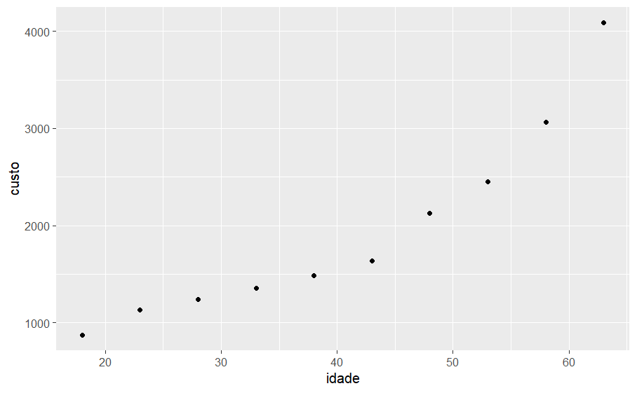

```r
ggplot(dados, aes(x=idade,y=custo)) + geom_point()
```

Observe que cada ponto é uma observação da tabela.

Onde:

Y: Variável Resposta Dependente X: Variável exploratória ou independente

Os dados estão correlacionados?

```r
result
```

```
    Spearman's rank correlation rho

data:  custo and idade
S = 3.6637e-14, p-value < 2.2e-16
alternative hypothesis: true rho is not equal to 0
sample estimates:
rho
  1
```

**Exercício 1**

Relação entre horas de estudo e desempenho em um teste

Suponha que temos dados sobre o tempo de estudo (em horas) e o desempenho em um teste (pontuação) de 50 alunos. Queremos verificar se os alunos que estudam mais tem melhor desempenho no teste.

```r
covariancia
```

```
[1] 3.466817
```

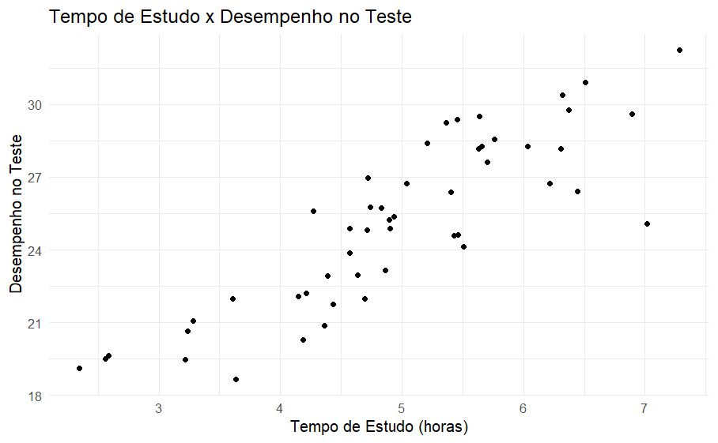

```r
data = data.frame(tempo_estudo,desempenho_teste)
ggplot(data, aes(x = tempo_estudo, y = desempenho_teste)) +
  geom_point() +
  theme_minimal() +
  labs(title = "Tempo de Estudo x Desempenho no Teste",
       x = "Tempo de Estudo (horas)",
       y = "Desempenho no Teste")
```

**Exercício 2**

Relação entre a quantidade de exercício físico e a frequência cardíaca

Suponha que temos dados sobre a quantidade de exercício físico (em minutos) e a frequência cardíaca (em batimentos por minuto) de 100 indivíduos. Queremos entender a relação entre as duas variáveis

```r
correlacao
```

```
[1] -0.8873667
```

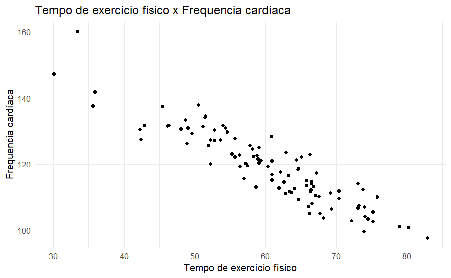

```r
data = data.frame(exercicio_fisico, frequencia_cardiaca)
ggplot(data, aes(x = exercicio_fisico, y = frequencia_cardiaca)) +
  geom_point() +
  theme_minimal() +
  labs(title = "Tempo de exercício físico x Frequencia cardíaca",
       x = "Tempo de exercício físico",
       y = "Frequencia cardíaca")
```

**Exercício 3**

Relação entre a quantidade de sono e a produtividade no trabalho

```r
correlacao
```

```
[1] 0.7099877
```

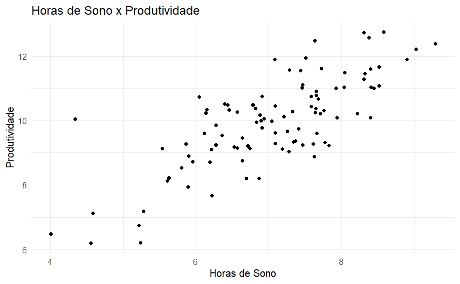

```r
data = data.frame(sono_horas,produtividade )
ggplot(data, aes(x = sono_horas, y = produtividade)) +
  geom_point() +
  theme_minimal() +
  labs(title = "Horas de Sono x Produtividade",
       x = "Horas de Sono",
       y = "Produtividade")
```

**Exercício 4**

Quantidade de horas de estudo e nível de ansiedade

```r
covariancia
```

```
[1] -1.338531
```

```r
#library(tidyverse)
data = data.frame(horas_estudo, nivel_ansiedade)
```

[figure not shown]

**Exercício 5**

Quantidade de exercício físico e calorias queimada durante o exercício

Suponha que temos dados sobre a quantidade de exercício físico (em minutos) e a quantidade de calorias queimadas durante o exercício de 100 indivíduos. Pretende-se entender a relação entre as variáveis

```r
correlacao
```

```
[1] -0.01888935
```

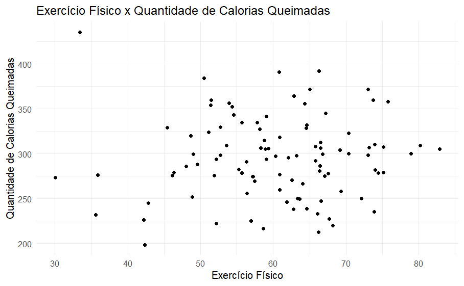

```r
library(tidyverse)
data = data.frame(exercicio_fisico, calorias_queimadas)
ggplot(data, aes(x = exercicio_fisico, y = calorias_queimadas)) +
  geom_point() +
  theme_minimal() +
  labs(title = "Exercício Físico x Quantidade de Calorias Queimadas",
       x = "Exercício Físico",
       y = "Quantidade de Calorias Queimadas")
```